# Aquaculture Deep Dive

By: Claire Gonzales

2022-08-16

## Initial data exploration

Hidden

## Metrics across top three sectors

### Aquaculture metric wrangling

Looking into aquaculture metrics

```r
aqdata <- read.csv(here("data", "Data_total_working_for_r_aq.csv"))
```

```r
aqdata_sub <- aqdata %>%
  filter(metric == "Aquaculture") %>%
  select("metric", "id", "title", "distance_to_shore", "depth_min", "depth_max", "depth_ave", "wave_height_average_m", "sst_c", "chla")

aqdata_sub_2 <- aqdata %>%
  filter(metric == "Aquaculture") %>%
  select("metric", "id", "title", "distance_to_shore", "depth_min", "depth_max", "depth_ave", "wave_height_average_m", "sst_c", "chla", "wind_present", "wave_present", "tidal_present", "other_present")


  # summarize(dist_median = median(distance_to_shore, na.rm = TRUE),
  #           depth_max_median = median(depth_max, na.rm = TRUE),
  #           sigwave_median = median(wave_height_average_m, na.rm = TRUE),
  #           sst_median = median(sst_c, na.rm = TRUE),
  #           chla_median = median(chla, na.rm = TRUE))
```

### Wind metric wrangling

Looking at wind metrics only

```r
winddata <- read.csv(here("data", "Data_total_working_for_r_wind.csv"))
```

```r
winddata_sub <- winddata %>%
  filter(metric == "Wind") %>%
  select("metric", "id", "title", "distance_to_shore", "depth_min", "depth_max", "depth_ave", "wave_height_average_m", "sst_c", "chla")


  # group_by(metric) %>%
  # summarize(dist_median = median(distance_to_shore, na.rm = TRUE),
  #           depth_max_median = median(depth_max, na.rm = TRUE),
  #           sigwave_median = median(wave_height_average_m, na.rm = TRUE),
  #           sst_median = median(sst_c, na.rm = TRUE),
  #           chla_median = median(chla, na.rm = TRUE))
```

### Wave metric wrangling

Only looking at wave metrics

```r
wavedata <- read.csv(here("data", "Data_total_working_for_r_wave.csv"))
```

```r
wavedata_sub <- wavedata %>%
  filter(metric == "Wave") %>%
  select("metric", "id", "title", "distance_to_shore", "depth_min", "depth_max", "depth_ave", "wave_height_average_m", "sst_c", "chla")
```

### Rbinding metrics from 3 sectors together

Creating ‘datadata’, which has all the metrics and is labeled by Aquaculture, Wind or Wave. DANGER: This data by nature has duplicates because some metrics in wave are also in wind, etc. **ONLY USE for graphing or to compare across sectors. Any examination of the data as a whole will be misleading.**

```r
datadata <- rbind(aqdata_sub, winddata_sub, wavedata_sub)
```

### Fig 4a code

Comparing listed depths across discipline (AQ, wave, and wind)

```r
fig4a <- ggplot(data = datadata, aes(x = metric, y = depth_ave)) +
  geom_beeswarm(size = 2, cex = 3, color = "darkgray") +
  #scale_color_manual(values = c("goldenrod2","cyan4","coral")) +
  geom_boxplot(fill = NA, width = 0.3, outlier.color = NA) +
  stat_summary(fun=median,
               geom="point",
               shape=20,
               size=3,
               color="black",
               fill="black") +
    labs(x = "Ocean activity",
         y = "Average depth (m)") +
  theme_minimal() +
  theme(legend.title = element_blank()) +
  scale_y_reverse()
```

### Fig 5a code

Comparing distances to shore across discipline (AQ, wave, and wind)

```r
fig5a <- ggplot(data = datadata, aes(x = metric, y = distance_to_shore)) +
  geom_beeswarm(color = "darkgray", size = 2, cex = 3) +
  geom_boxplot(fill = NA, width = 0.3, outlier.color = NA) +
  stat_summary(fun=median,
               geom="point",
               shape=20,
               size=3,
               color="black",
               fill="black") +
  labs(x = "Ocean activity",
       y = "Distance from shore (m)") +
  theme_minimal() +
  theme(legend.title = element_blank(), legend.position = "none")
```

## Other metric comparisons (low n values)

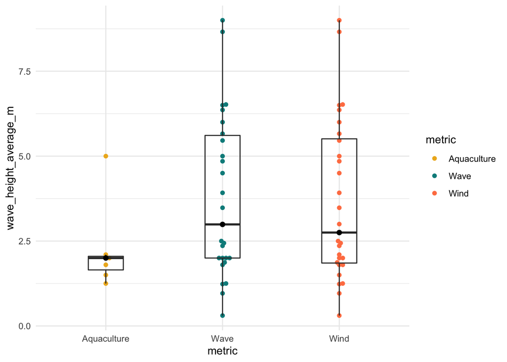

```r
ggplot(data = datadata, aes(x = metric, y = wave_height_average_m)) +
  geom_beeswarm(aes(color = metric)) +
  scale_color_manual(values = c("goldenrod2","cyan4","coral")) +
  geom_boxplot(fill = NA, width = 0.3, outlier.color = NA) +
  stat_summary(fun=median,
               geom="point",
               shape=20,
               size=3,
               color="black",
               fill="black") +
  theme_minimal()
```

Comparing SSTs (degrees celcius) across disciplines

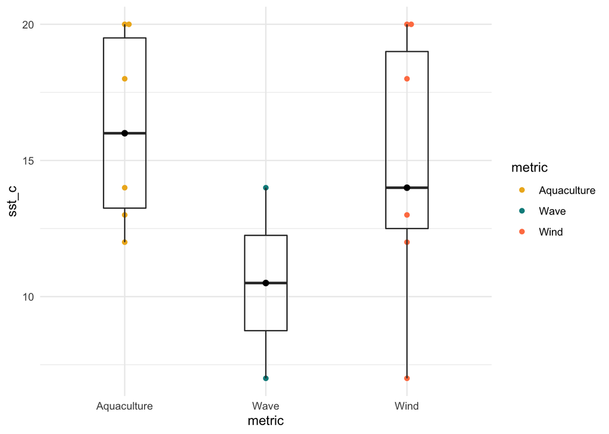

```r
ggplot(data = datadata, aes(x = metric, y = sst_c)) +
  geom_beeswarm(aes(color = metric)) +
  scale_color_manual(values = c("goldenrod2","cyan4","coral")) +
  geom_boxplot(fill = NA, width = 0.3, outlier.color = NA) +
  stat_summary(fun=median,
               geom="point",
               shape=20,
               size=3,
               color="black",
               fill="black") +
  theme_minimal()
```

## Examining aquaculture metrics ONLY

Using ‘aqdata_sub_2’ from above to examine aquacutlure metrics more closely.

### What is aquaculture being co-located with?

Creating a dataset called ‘alltogether’ that shows aquaculture metrics, grouped by the activity it is being co-located with (aka the “buddy”)

```r
aqua_wind <- aqdata_sub_2 %>%
  filter(wind_present == "1") %>%
  mutate(buddy = rep("Wind", 16))
```

```r
aqua_wave <- aqdata_sub_2 %>%
  filter(wave_present == "1") %>%
  mutate(buddy = rep("Wave", 4))
```

```r
aqua_tidal <- aqdata_sub_2 %>%
  filter(tidal_present == "1") %>%
  mutate(buddy = rep("Tidal", 2))
```

```r
aqua_other <- aqdata_sub_2 %>%
  filter(other_present == "1") %>%
  mutate(buddy = rep("Other", 7))
```

```r
alltogether <- as_tibble(rbind(aqua_wind, aqua_wave, aqua_tidal, aqua_other))

alltogether$buddy <- factor(alltogether$buddy,
                            levels = c("Wind",
                                       "Wave",
                                       "Tidal",
                                       "Other"))
```

Graphing the depth differences of aquaculture at different depths. **DANGER: this data set is misleading because of duplicates/overlapping values across buddies that here are being depicted as different values**

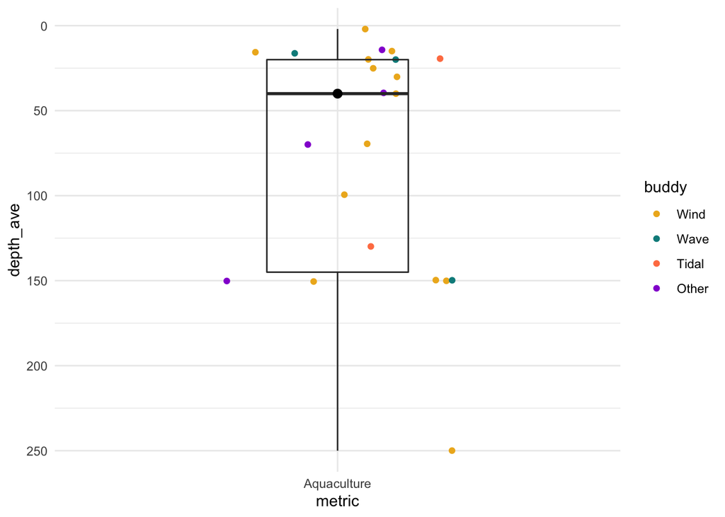

```r
ggplot(data = alltogether, aes(x = metric, y = depth_ave)) +
  geom_jitter(aes(color = buddy), width = 0.25) +
  scale_color_manual(values = c("goldenrod2","cyan4","coral", "darkviolet")) +
  geom_boxplot(fill = NA, width = 0.3, outlier.color = NA) +
  stat_summary(fun=median,
               geom="point",
               shape=20,
               size=4,
               color="black",
               fill="black") +
  theme_minimal() +
  scale_y_reverse()
```

```r
# I like this figure but I think it's too misleading so I shouldn't use
```

Graphing the depth differences of aquaculture at different “buddies”

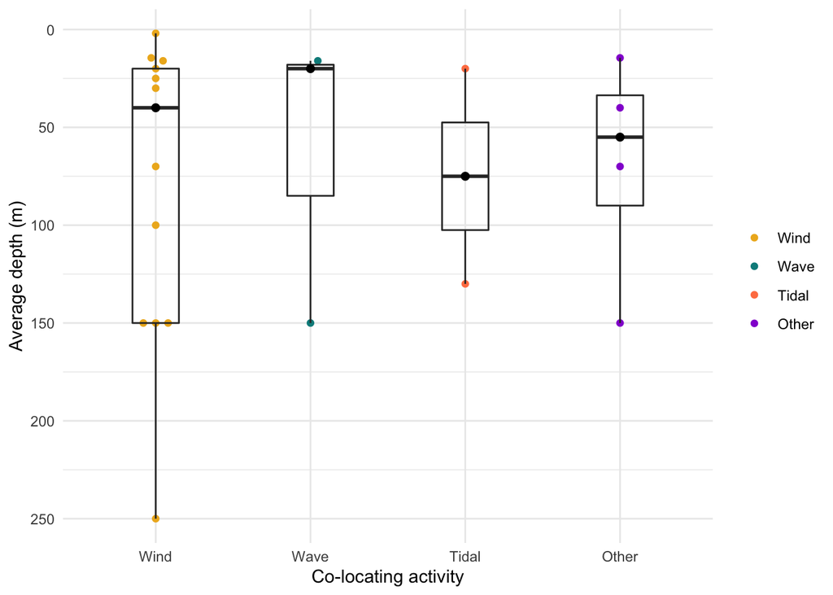

```r
# original code with color coding. Potential code for shape coding in next code chunk

ggplot(data = alltogether, aes(x = buddy, y = depth_ave)) +
  geom_beeswarm(aes(color = buddy), cex = 2) +
  scale_color_manual(values = c("goldenrod2","cyan4","coral", "darkviolet")) +
  geom_boxplot(fill = NA, width = 0.3, outlier.color = NA) +
  stat_summary(fun=median,
               geom="point",
               shape=20,
               size=3,
               color="black",
               fill="black") +
  labs(x = "Co-locating activity",
       y = "Average depth (m)") +
  theme_minimal() +
  theme(legend.title = element_blank()) +
  scale_y_reverse()
```

Graphing the depth differences of aquaculture at different distances from shore **DANGER: same misleading data issue as above**

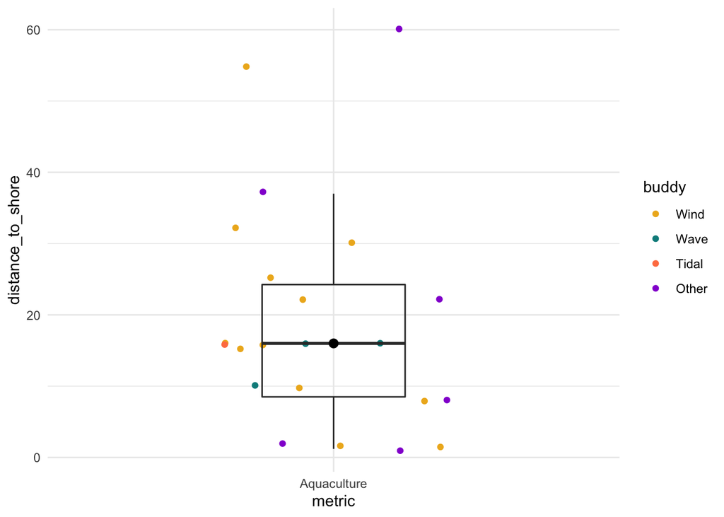

```r
ggplot(data = alltogether, aes(x = metric, y = distance_to_shore)) +
  geom_jitter(aes(color = buddy), width = 0.25) +
  scale_color_manual(values = c("goldenrod2","cyan4","coral", "darkviolet")) +
  geom_boxplot(fill = NA, width = 0.3, outlier.color = NA) +
  stat_summary(fun=median,
               geom="point",
               shape=20,
               size=4,
               color="black",
               fill="black") +
  theme_minimal()
```

Graphing the differences in distance to shore of aquaculture across different “buddies”

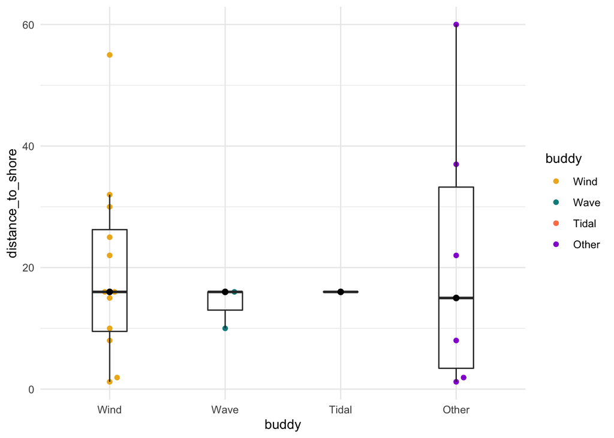

```r
ggplot(data = alltogether, aes(x = buddy, y = distance_to_shore)) +
  geom_beeswarm(aes(color = buddy), cex = 2) +
  scale_color_manual(values = c("goldenrod2","cyan4","coral", "darkviolet")) +
  geom_boxplot(fill = NA, width = 0.3, outlier.color = NA) +
  stat_summary(fun=median,
               geom="point",
               shape=20,
               size=3,
               color="black",
               fill="black") +
  theme_minimal()
```

## Plan for Fig 4&5

Here, I am trying something new. Instead of having the Fig 4 panes of ave depth and distance from shore for aqua, wave and wind and THEN having a fig 5 of panes with the buddy of aqua dataset, This section will try having:

fig 4a: Ave Depth of aqua, wave and wind fig 4b: co-location “buddies” of aqua depth metrics fig 5a: Distance from shore of aqua, wave and wind fig 5b: co-location “buddies” of aqua distance from shore metrics

### Fig 4b code

```r
fig4b <- ggplot(data = alltogether, aes(x = buddy, y = depth_ave)) +
  geom_beeswarm(cex = 3, size = 2) +
 # scale_color_manual(values = c("goldenrod2","cyan4","coral", "darkviolet")) +
  # geom_boxplot(
  #   #data = aqdata_sub_2,
  #   fill = NA, width = 0.3, outlier.color = NA) +
  # stat_summary(fun=median,
  #              geom="point",
  #              shape=20,
  #              size=3,
  #              color="black",
  #              fill="black") +
  labs(x = "Aquaculture co-located activity",
       y = "Average depth (m)") +
  theme_minimal() +
  theme(
    #axis.text.x = element_text(angle=60),
        legend.title = element_blank()) +
  scale_y_reverse()
```

### Fig 5b code

```r
fig5b <- ggplot(data = alltogether, aes(x = buddy, y = distance_to_shore)) +
  geom_beeswarm(cex = 3, size = 2) +
  scale_color_manual(values = c("goldenrod2","cyan4","coral", "darkviolet")) +
  labs(x = "Aquaculture co-located activity",
       y = "Distance from shore (m)") +
  theme_minimal() +
  theme(legend.title = element_blank())
```

### Patching fig 4 together

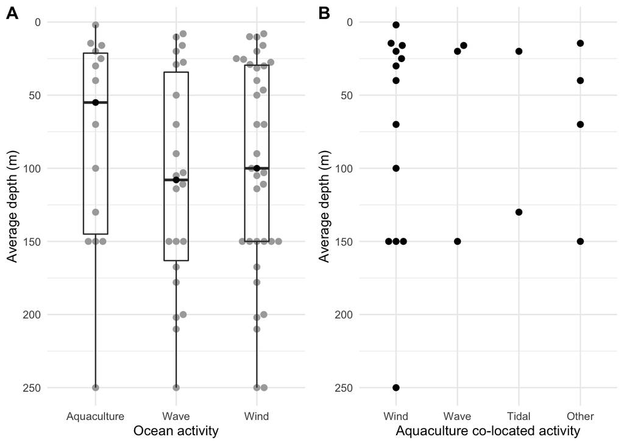

```r
#legend <- get_legend(fig4a)

plot_grid(
  fig4a + theme(legend.position = "none"),
  fig4b + theme(legend.position = "none"),
  align = "vh",
  labels = c("A", "B"))
```

**Figure 4.** Shows (A) the average depth (meters) across aquaculture (n = 14), wave energy (n = 22), and wind energy (n = 35) sectors. These three ocean activities all reflect similar average reported depths (Kruskal-Wallis p = 0.467)…

### writing jpeg for fig4

### Patching fig 5 together

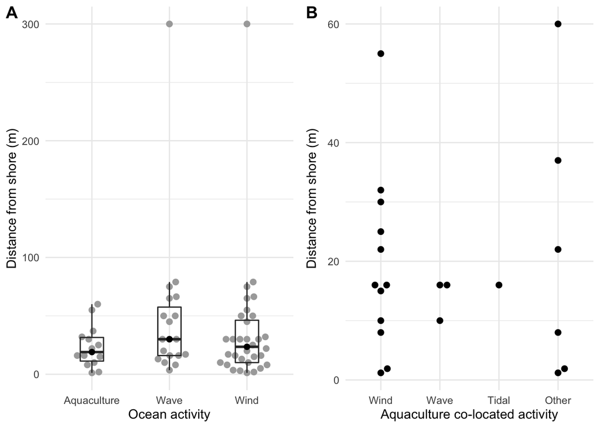

```r
#legend <- get_legend(fig4a)

plot_grid(
  fig5a + theme(legend.position = "none"),
  fig5b + theme(legend.position = "none"),
  align = "vh",
  labels = c("A", "B"))
```

**Figure 5.** Pane (A) shows the distance from shore (meters) across aquaculture (n = 14), wave energy (n = 19), and wind energy (n = 32). These sectors all reflect similar distances from shore (Kruskal-Wallis p = 0.337). Pane (B) …

### writing jpeg for fig5

### Kruskal-Wallis of aquaculture metrics

Comparing aquaculture metrics against wind and wave

```r
datadata_anova <- aov(depth_ave ~ metric, data = datadata)

summary(datadata_anova)
```

```
##             Df Sum Sq Mean Sq F value Pr(>F)
## metric       2   6548    3274   0.601  0.551
## Residuals   68 370487    5448
## 25 observations deleted due to missingness
```

```r
# depth_ave: p-value = 0.551
# distance to shore: p-value = 0.394
```

Making the same comparison using a Kruskal-Wallis test.

```r
datadata_kruswall <- kruskal.test(depth_ave ~ metric, data = datadata)

datadata_kruswall
```

```
##
##  Kruskal-Wallis rank sum test
##
## data:  depth_ave by metric
## Kruskal-Wallis chi-squared = 1.5214, df = 2, p-value = 0.4673
```

```r
# depth_ave: p-value = 0.4673
# distance to shore: p-value = 0.3366
```

Kruskal Wallis test is the better test for this data because we violate the assumtions of the ANOVA, but a Kruskal Wallis test does not require these assumptions. Kruskal Wallis is non-parametric and ranks-based assessment of medians.

```r
alltogether_kruswall_depth <- kruskal.test(depth_ave ~ buddy, data = alltogether)

alltogether_kruswall_depth
```

```
##
##  Kruskal-Wallis rank sum test
##
## data:  depth_ave by buddy
## Kruskal-Wallis chi-squared = 0.15273, df = 3, p-value = 0.9848
```

```r
# Kruskal-Wallis chi-squared = 0.15273, df = 3, p-value = 0.9848

alltogether_kruswall_dist <- kruskal.test(distance_to_shore ~ buddy, data = alltogether)

alltogether_kruswall_dist
```

```
##
##  Kruskal-Wallis rank sum test
##
## data:  distance_to_shore by buddy
## Kruskal-Wallis chi-squared = 0.10674, df = 3, p-value = 0.991
```

```r
# Kruskal-Wallis chi-squared = 0.10674, df = 3, p-value = 0.991
```

### Sample sizes

Determining the n values of distance from shore and average depth for each ocean activity in datadata

summary_datadata has the median values nvals_datadata has the n values

```r
summary_datadata <- datadata %>%
  group_by(metric) %>%
  summarize(median_depth = median(depth_ave, na.rm = TRUE),
            median_dist = median(distance_to_shore, na.rm = TRUE))


nvals_datadata_depth <- datadata %>%
  filter(depth_ave != "NA") %>%
  group_by(metric) %>%
  summarize(n_depth = n())

nvals_datadata_dist <- datadata %>%
  filter(distance_to_shore != "NA") %>%
  group_by(metric) %>%
  summarize(n_dist = n()) %>%
  rename(metric_dist = metric) #renaming because r was getting confused by 2 columns with same name in cbind()

nvals_datadata <- as_tibble(cbind(nvals_datadata_depth, nvals_datadata_dist)) %>%
  select("metric", "n_depth", "n_dist")
```

Determining the n values of distance from shore and average depth for each ocean activity in alltogether

summary_alltogether has the median values nvals_alltogether has the n values

```r
summary_alltogether <- alltogether %>%
  group_by(buddy) %>%
  summarize(median_depth = median(depth_ave, na.rm = TRUE),
            median_dist = median(distance_to_shore, na.rm = TRUE),
            max_depth = max(depth_max, na.rm = TRUE),
            min_depth = min(depth_min, na.rm = TRUE),
            max_dist = max(distance_to_shore, na.rm = TRUE),
            min_dist = min(distance_to_shore, na.rm = TRUE))
```